← Back to RTM-Suite

# SCOPEinR — Complete Reference Manual

Running the SCOPE 2.0 soil-canopy-energy-fluorescence model in R, verified by real execution

2026-08-20

# What this manual is

```r
library(ToolsRTM)
library(SCOPEinR)
cat("ToolsRTM ", as.character(packageVersion("ToolsRTM")),
    " | SCOPEinR ", as.character(packageVersion("SCOPEinR")), "\n", sep = "")
```

```
## ToolsRTM 0.62.5 | SCOPEinR 0.46
```

# SCOPE, and how SCOPEinR relates to ToolsRTM

**SCOPE** (Soil Canopy Observation, Photochemistry and Energy fluxes) is a coupled radiative-transfer/energy-balance model of a vegetated surface (Van der Tol et al. 2009; Yang et al. 2020, SCOPE 2.0). Given leaf biochemistry, canopy structure, viewing/illumination geometry and meteorology, it simultaneously solves for:

- **Radiative transfer**: canopy reflectance and top-of-canopy radiance, in the same sense as PROSAIL/4SAIL.
- **Energy balance**: how absorbed radiation partitions into sensible heat, latent heat (transpiration/evaporation) and soil heat flux, for both the canopy and the soil, at leaf/soil temperatures that are solved for rather than prescribed.
- **Photosynthesis / biochemistry**: leaf-level CO₂ assimilation (a Farquhar–von Caemmerer–Berry / Collatz-type C3/C4 model) driven by the absorbed light and the solved leaf temperature.
- **Chlorophyll fluorescence**: sun-induced fluorescence (SIF) emission, linked mechanistically to the photosynthesis/NPQ (non-photochemical quenching) state of the leaf, and propagated through the canopy to a top-of-canopy radiance.

# Installation and loading

Both packages are distributed from public GitLab repositories and, in this environment, are already installed:

```r
if (!requireNamespace("remotes", quietly = TRUE)) install.packages("remotes")
remotes::install_gitlab("caminoccg/toolsrtm", upgrade = "never")
remotes::install_gitlab("caminoccg/scopeinr", upgrade = "never")
```

`library(SCOPEinR)` on its own is not enough — always load `ToolsRTM` first (or alongside it), since SCOPEinR’s `get.SCOPE()` dispatches leaf and canopy optics straight into `ToolsRTM` functions.

# Input structure

SCOPE needs two kinds of input beyond the leaf/canopy traits ToolsRTM already required for PROSAIL: **simulation options** (which sub-models to switch on) and a **parameter table** with the added biochemical, meteorological and geometric fields the energy balance needs. Both ship inside the installed package under `inst/input/`, resolved here with `system.file()` so the paths work regardless of the current working directory:

```r
path_input <- system.file("input", package = "SCOPEinR")
list.files(path_input)
```

```
##  [1] "input_borders.csv"      "input_data_default.csv" "inputs_SCOPE.csv"
##  [4] "inputs_SCOPE.xlsx"      "leafangles"             "LUT_input.csv"
##  [7] "mSCOPE.csv"             "radiationdata"          "setoptions.csv"
## [10] "soil_spectra"
```

## `setoptions.csv` — simulation options

```r
scope_options <- read.table(file.path(path_input, "setoptions.csv"),
                             header = TRUE, sep = ",")
scope_options[, c("Options", "Value")]
```

```
##                 Options Value
## 1                  lite     1
## 2     calc_fluorescence     1
## 3  calc_spectrum_planck     1
## 4   calc_xanthophyllabs     1
## 5          soilspectrum     0
## 6    Fluorescence_model     0
## 7             applTcorr     1
## 8                verify     1
## 9                mSCOPE     0
## 10           simulation     0
## 11     calc_directional     0
## 12   calc_vert_profiles     0
## 13     soil_heat_method     2
## 14         calc_rss_rbs     0
## 15         MoninObukhov     1
## 16                 LIDF     0
## 17           irradiance     0
```

Each row switches a SCOPE sub-model or numerical behaviour on/off (`0`/`1`) or picks a variant (e.g. `Fluorescence_model`). The ones that matter most for what follows: `calc_fluorescence = 1` turns on the Fluspect/RTMf fluorescence chain (without it, `data.rad$reflapp` and the `fluorescence_*` outputs are not produced); `calc_spectrum_planck = 1` turns on the thermal-emission spectrum; `soil_heat_method = 2` picks how the soil heat flux `G` is estimated (`0.35 * Rn` when not running a time series); `LIDF = 0` means the leaf-inclination distribution is built from `LIDFa`/`LIDFb` in the LUT rather than from a measured-angles file.

## Parameter tables: `LUT_input.csv` and `inputs_SCOPE.csv`

`LUT_input.csv` is a ready-to-run, single-row example parameter set (one SCOPE simulation) with every column SCOPE expects — leaf biochemistry (`N`, `Cab`, `Car`, …), photosynthetic capacity (`Vcmax25`, `BallBerrySlope`, …), canopy structure (`LAI`, `hc`, `LIDFa`, `LIDFb`, …), soil/meteorology (`Ta`, `Rin`, `Rli`, `p`, `ea`, `RH`, `u`, …) and viewing/illumination geometry (`tts`, `tto`, `psi`):

```r
LUT_default <- read.table(file.path(path_input, "LUT_input.csv"),
                           header = TRUE, sep = ",")
dim(LUT_default)
```

```
## [1]  1 77
```

```r
LUT_default[1, c("N","Cab","Car","LAI","Vcmax25","tts","tto","Ta","Rin")]
```

```
##     N Cab Car LAI Vcmax25 tts tto Ta Rin
## 1 1.5  60  10   3      60  30   0 20 600
```

`inputs_SCOPE.csv` is the companion *ranges* table used to generate new, randomized parameter sets (Section 6): one row per variable, with a `lower`/`upper` bound, a sampling `Distribution` (`Uniform`, `Gaussian` or `Fixed`), and a `default` value used when the variable is held fixed.

```r
inputLUT <- read.table(file.path(path_input, "inputs_SCOPE.csv"),
                        header = TRUE, sep = ",")
inputLUT[inputLUT$variable %in% c("Cab","LAI","Vcmax25","EWT","LIDFa","tts"),
         c("variable","lower","upper","Distribution","default")]
```

```
##    variable lower upper Distribution default
## 2       Cab  5.00  90.0     Gaussian  40.000
## 6       EWT  0.00   0.2      Uniform   0.009
## 15  Vcmax25  0.75 250.0      Uniform  70.000
## 40      LAI  0.10   7.0      Uniform   3.000
## 42    LIDFa -1.00   1.0      Uniform  -0.350
## 74      tts  0.00  15.0      Uniform  30.000
```

# A single simulation with `get.SCOPE()`

The default `LUT_input.csv` row plus the default options are enough to run one full simulation. `optipar` selects the wavelength-dependent leaf optical coefficients for the chosen `leaf.model` — `optipar2021.Pro.CX` pairs with `leaf.model = "fluspect-CX"` (PROSPECT-PRO pigment set, plus the `Cx` xanthophyll de-epoxidation state for PRI-type simulations).

```r
invisible(capture.output(
  db.sim <- SCOPEinR::get.SCOPE(
    LUT           = LUT_default[1, ],
    options.SCOPE = scope_options,
    optipar       = SCOPEinR::optipar2021.Pro.CX,
    leaf.model    = "fluspect-CX",
    canopy.model  = "fourSAIL",
    get.outputs   = "ALL",
    get.plots     = FALSE
  )
))
```

`get.SCOPE()` always returns a **list of simulations** (one element per LUT row); for a single row that is a list of length 1, and `db.sim[[1]]` is itself a list with 19 named elements:

```r
length(db.sim)
```

```
## [1] 1
```

```r
length(db.sim[[1]])
```

```
## [1] 19
```

```r
names(db.sim[[1]])
```

```
##  [1] "data.spectral"    "data.angles"      "data.rad"         "atmo"
##  [5] "resist_out"       "data.fluxes"      "data.soil"        "data.leafopt"
##  [9] "data.leafbio"     "data.canopy"      "data.profiles"    "data.gap"
## [13] "data.meteo"       "data.thermal"     "data.bcu"         "data.bch"
## [17] "data.directional" "iter.ebal"        "data.opts"
```

The elements that matter for everyday use:

| Element | Contents |
| --- | --- |
| `data.rad` | Reflectance/radiance/irradiance spectra (`rdd`, `rdo`, `rsd`, `rso`, `refl`, `reflapp`, `Lo_`, `Esun_`, `Esky_`, fluorescence spectra, absorbed-PAR terms, …) — 87 fields |
| `data.fluxes` | Scalar energy/carbon fluxes: `Rnctot`, `lEctot`, `Hctot`, `Actot`, `Tcave`, and the soil/total equivalents |
| `data.thermal` | Solved sunlit/shaded canopy and soil temperatures (`Tcu`, `Tch`, `Tsu`, `Tsh`) |
| `data.bcu` / `data.bch` | Biochemical model state for sunlit (`bcu`) / shaded (`bch`) leaves: `A` (assimilation), `Ja` (electron transport), `Kn` (NPQ), `eta` (fluorescence yield factor) |
| `data.canopy`, `data.leafbio`, `data.soil`, `data.meteo`, `data.angles` | Echo back the resolved canopy/leaf/soil/meteo/geometry inputs actually used |
| `iter.ebal` | Energy-balance solver diagnostics: iteration `counter`, `maxit`, and the residual `maxEBercu`/`maxEBerch`/`maxEBers` errors (canopy sunlit/shaded/soil) |
| `data.opts`, `data.spectral`, `data.gap`, `data.profiles`, `data.directional`, `atmo`, `resist_out` | Options actually used, wavelength grid, gap probabilities, vertical profiles, directional (BRDF) output, atmosphere, aerodynamic/surface resistances |

```r
db.sim[[1]]$data.fluxes
```

```
## $Rnctot
## [1] 381.7305
##
## $lEctot
## [1] 131.1323
##
## $Hctot
## [1] 250.724
##
## $Actot
## [1] 19.8942
##
## $Tcave
## [1] 22.04278
##
## $Rnstot
## [1] 114.9653
##
## $lEstot
## [1] 50.53012
##
## $Hstot
## [1] 24.25024
##
## $Gtot
## [1] 40.23785
##
## $Tsave
## [1] 26.7952
##
## $Rntot
## [1] 496.6957
##
## $lEtot
## [1] 181.6625
##
## $Htot
## [1] 274.9742
```

```r
db.sim[[1]]$iter.ebal
```

```
## $counter
## [1] 7
##
## $maxit
## [1] 100
##
## $maxEBercu
## [1] 0.0365275
##
## $maxEBerch
## [1] 0.08928034
##
## $maxEBers
## [1] 0.1082583
```

`iter.ebal$counter` is how many iterations the energy-balance solver used to converge; `maxEBercu`/`maxEBerch`/`maxEBers` are its final canopy sunlit/shaded/soil residual errors.

# Reflectance components: `rdd`, `rdo`, `rsd`, `rso`, `refl`, `reflapp`

SCOPE separates canopy reflectance into four bidirectional components before summing them, plus the sensor-observed “apparent” reflectance:

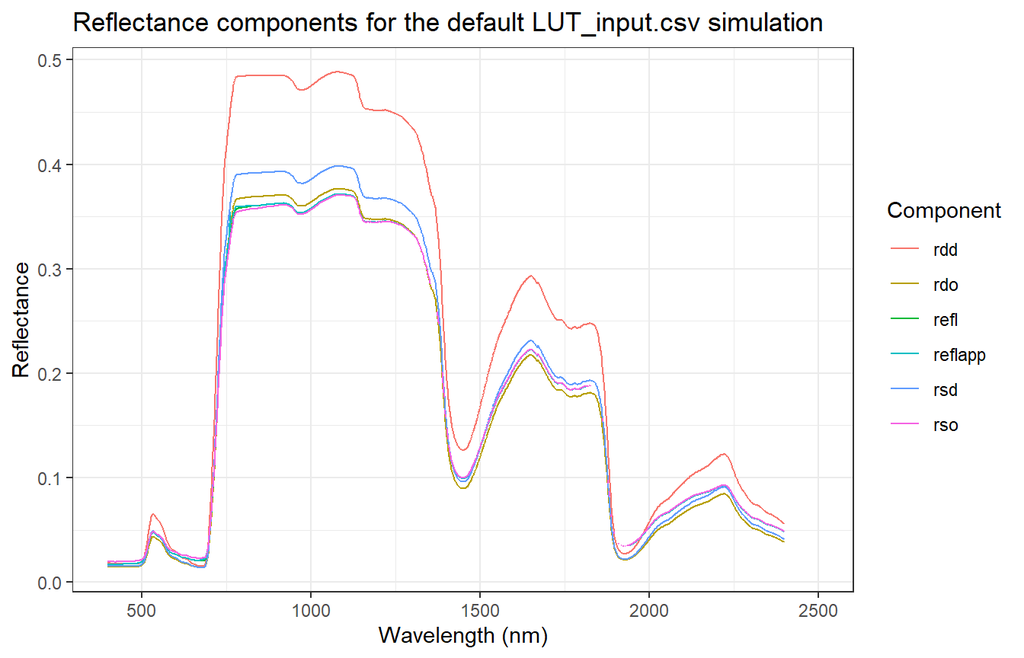

```r
bands <- SCOPEinR::define.bands()
wlS <- bands$wlS[1:2001]   # 400-2500 nm, shortwave-only part of data.rad's 2162-length vectors

rad <- db.sim[[1]]$data.rad
refl_components <- data.frame(
  Wavelength = rep(wlS, 6),
  Value = c(rad$rdd[1:2001], rad$rdo[1:2001], rad$rsd[1:2001],
            rad$rso[1:2001], rad$refl[1:2001], rad$reflapp[1:2001]),
  Component = rep(c("rdd","rdo","rsd","rso","refl","reflapp"), each = 2001)
)

library(ggplot2)
ggplot(refl_components, aes(x = Wavelength, y = Value, color = Component)) +
  geom_line(linewidth = 0.5) +
  theme_bw() + xlim(400, 2500) +
  xlab("Wavelength (nm)") + ylab("Reflectance") +
  ggtitle("Reflectance components for the default LUT_input.csv simulation")
```

`reflapp` tracks `refl` closely outside the fluorescence band but departs from it around 640-850nm — the signature of SCOPE’s fluorescence emission riding on top of the reflected signal, exactly what a real sensor would pick up in that region.

# Building a randomized LUT with `getLUT.SCOPE()`

`getLUT.SCOPE(inputLUT, nLUT, setseed)` samples `nLUT` parameter sets from the ranges table read above: `Uniform` rows are sampled with `stats::runif()`, `Fixed` rows are repeated at their `default`, and anything else (`Gaussian`) is sampled with `ToolsRTM::gauss_byMin_Max()` (truncated Gaussian within `[lower, upper]`, centered at `Mean_D` with spread `Std_D`).

```r
n_samples <- 10
LUT <- getLUT.SCOPE(inputLUT = inputLUT, nLUT = n_samples, setseed = 42)
dim(LUT)
```

```
## [1] 10 76
```

```r
summary(LUT[, c("Cab","LAI","Vcmax25")])
```

```
##       Cab             LAI           Vcmax25
##  Min.   :22.22   Min.   :1.020   Min.   : 29.71
##  1st Qu.:44.34   1st Qu.:1.938   1st Qu.: 47.81
##  Median :47.61   Median :3.754   Median : 96.58
##  Mean   :51.67   Mean   :3.726   Mean   : 97.08
##  3rd Qu.:60.26   3rd Qu.:5.494   3rd Qu.:137.01
##  Max.   :80.23   Max.   :6.434   Max.   :182.64
```

```r
lidf_cor <- suppressMessages(ToolsRTM::getCor(
  n_inputs = 2, setseed = 7, distribution = "Uniform",
  nLUT = n_samples, rho = 0.20, Varnames = c("LIDFa", "LIDFb"),
  MinRange = c(-0.5, -0.5), MaxRange = c(0.2, 0.2)
))
LUT$LIDFa <- lidf_cor$LUT$LIDFa
LUT$LIDFb <- lidf_cor$LUT$LIDFb
cat("Achieved correlation:", round(cor(LUT$LIDFa, LUT$LIDFb), 2), "\n")
```

```
## Achieved correlation: -0.06
```

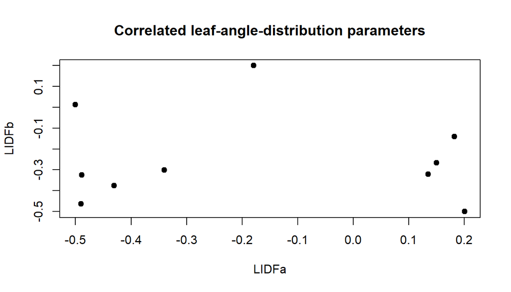

```r
plot(LUT$LIDFa, LUT$LIDFb, xlab = "LIDFa", ylab = "LIDFb",
     main = "Correlated leaf-angle-distribution parameters", pch = 19)
```

# Running many simulations: serial vs. parallel

`get.SCOPE()` accepts a multi-row `LUT` directly and loops over it serially (`n.LUT` must match `nrow(LUT)`). `get.SCOPE.parallel()` splits the same LUT into `n.cores` chunks, runs them on a `parallel`/`doParallel` PSOCK cluster, and (optionally) writes CSV outputs itself. Timed back-to-back on the same 10-row LUT:

```r
t0 <- Sys.time()
sims_serial <- SCOPEinR::get.SCOPE(
  LUT = LUT, n.LUT = n_samples, options.SCOPE = scope_options,
  optipar = SCOPEinR::optipar2021.Pro.CX, leaf.model = "fluspect-CX",
  canopy.model = "fourSAIL", get.outputs = "ALL", get.plots = FALSE
)
t_serial <- as.numeric(Sys.time() - t0, units = "secs")

t0 <- Sys.time()
sims_parallel <- SCOPEinR::get.SCOPE.parallel(
  LUT = LUT, options.SCOPE = scope_options, optipar = SCOPEinR::optipar2021.Pro.CX,
  leaf.model = "fluspect-CX", canopy.model = "fourSAIL",
  parallel = TRUE, n.cores = 4, get.outputs = "ALL",
  get.plots = FALSE, get.csv = FALSE
)
```

```
## Total simulations: 10
## Total execution time: 8.91504
```

```r
t_parallel <- as.numeric(Sys.time() - t0, units = "secs")

cat("Serial (1 core):    ", round(t_serial, 1), "s for", length(sims_serial), "sims\n")
```

```
## Serial (1 core):     12.8 s for 10 sims
```

```r
cat("Parallel (4 cores):  ", round(t_parallel, 1), "s for", length(sims_parallel), "sims\n")
```

```
## Parallel (4 cores):   10.7 s for 10 sims
```

For a LUT this small the parallel path still pays a fixed cost — spinning up a PSOCK cluster and exporting `SCOPEinR`/`ToolsRTM` to every worker — so the speed-up is modest here; it becomes worthwhile once `nLUT` is in the hundreds/thousands, which is the realistic use case for `get.LUT()` + inversion training data.

## The chunked production pattern

For large LUTs, Carlos’s real workflow (`Scripts/R/ForSCOPE/1-getSCOPE-v3_withChunck.R`) splits the LUT into chunks and calls `get.SCOPE.parallel()` once per chunk with `get.csv = TRUE`, so intermediate results are written to disk instead of being held in memory all at once:

```r
# A dedicated, larger LUT for this section -- get.SCOPE.plots() (Section 8)
# needs at least 10 simulations per chunk to have something to bin, and the
# inversion demo below (Section 11) reuses this same data: get.inversion()
# uses 10-fold x 10-repeat cross-validation internally, which needs enough
# rows per fold to fit PLSR/RF reliably -- 20 total (14 in the 70% training
# split) is too few and makes caret::train() fail.
n_prod <- 60
LUT_prod <- getLUT.SCOPE(inputLUT = inputLUT, nLUT = n_prod, setseed = 43)
lidf_cor_prod <- suppressMessages(ToolsRTM::getCor(
  n_inputs = 2, setseed = 8, distribution = "Uniform",
  nLUT = n_prod, rho = 0.20, Varnames = c("LIDFa", "LIDFb"),
  MinRange = c(-0.5, -0.5), MaxRange = c(0.2, 0.2)
))
LUT_prod$LIDFa <- lidf_cor_prod$LUT$LIDFa
LUT_prod$LIDFb <- lidf_cor_prod$LUT$LIDFb

out_root <- paste0(tempdir(), "/scope_outs/")   # trailing slash required by path.out below
dir.create(out_root, showWarnings = FALSE, recursive = TRUE)

n_chunks   <- 2
n_rows     <- nrow(LUT_prod)
chunk_size <- n_rows / n_chunks

for (i in seq_len(n_chunks)) {
  start_row <- ((i - 1) * chunk_size) + 1
  end_row   <- min(i * chunk_size, n_rows)
  LUT_chunk <- LUT_prod[start_row:end_row, ]

  SCOPEinR::get.SCOPE.parallel(
    LUT           = LUT_chunk,
    options.SCOPE = scope_options,
    optipar       = SCOPEinR::optipar2021.Pro.CX,
    leaf.model    = "fluspect-CX",
    canopy.model  = "fourSAIL",
    parallel      = TRUE,
    n.cores       = 4,
    get.outputs   = "ALL",
    get.plots     = FALSE,
    get.csv       = TRUE,
    path.out      = out_root
  )
}
```

```r
subdirs <- list.dirs(out_root, recursive = FALSE)
basename(subdirs)
```

```
## [1] "2026-08-20_17-19-34" "2026-08-20_17-19-58"
```

`get.SCOPE.parallel()`/`get.SCOPE.outputs()` build the timestamped output folder with `paste(path.out, current_time, sep = "")` — plain string concatenation, not `file.path()`. **`path.out` must end in `/`**, or the “subfolder” ends up as a sibling directory with the timestamp glued onto its name instead of nested inside it (an easy trap; `tempdir()` never ends in a slash on its own).

# Exploring SCOPE outputs

Each chunk folder holds one CSV per output variable, plus a `Parameters/` subfolder with the exact LUT used:

```r
last_subdir <- subdirs[length(subdirs)]
list.files(last_subdir)
```

```
##  [1] "aPAR.csv"                      "Eout_spectrum.csv"
##  [3] "Esky.csv"                      "Esun.csv"
##  [5] "fluorescence.csv"              "fluorescence_All_Leaves.csv"
##  [7] "fluorescence_hemis.csv"        "fluorescence_ReabsCorr.csv"
##  [9] "fluorescence_scalar.csv"       "fluorescence_scalar_units.csv"
## [11] "fluorescence_scattered.csv"    "fluorescence_shaded.csv"
## [13] "fluorescence_soil.csv"         "fluorescence_sunlit.csv"
## [15] "fluxes.csv"                    "fluxes_units.csv"
## [17] "Lo_spectrum.csv"               "Lo_spectrum_includingF.csv"
## [19] "Parameters"                    "radiation.csv"
## [21] "radiation_units.csv"           "rdd.csv"
## [23] "rdo.csv"                       "refl.csv"
## [25] "reflapp.csv"                   "resistance.csv"
## [27] "resistance_units.csv"          "rsd.csv"
## [29] "rso.csv"                       "SigmaF.csv"
## [31] "vegatation.csv"                "vegatation_units.csv"
```

```r
list.files(file.path(last_subdir, "Parameters"))
```

```
## [1] "inputLUT.csv"     "SCOPEversion.txt"
```

One CSV per output variable (`fluxes.csv`, `reflapp.csv`, …), plus the exact input LUT that produced them saved alongside for reproducibility.

## Merging chunks

Reading each chunk’s CSV directly and row-binding across chunk folders merges chunked output back into one table:

```r
fluxes_all <- do.call(rbind, lapply(subdirs, function(d) read.csv(file.path(d, "fluxes.csv"))))
dim(fluxes_all)
```

```
## [1] 60 14
```

```r
head(fluxes_all[, c("Rnctot","Actot","Tcave","Rnstot","Tsave")])
```

```
##     Rnctot      Actot    Tcave     Rnstot    Tsave
## 1 530.7934 22.7952724 22.14358  39.489187 23.42798
## 2 582.9905 20.2861382 22.46935  10.602271 25.42557
## 3 616.1376 26.2266501 22.12216   9.564002 25.13658
## 4 201.9446  0.9033706 21.84580 272.589532 26.79398
## 5 425.9027 27.2858073 22.87809 104.218383 25.02557
## 6 596.2558 26.0440659 21.19897  17.022793 23.27270
```

## Plotting: `get.SCOPE.plots()`

`get.SCOPE.plots(path.files, plant.trait, get.plots)` groups a chunk’s spectra by an input trait (into 8 bins) and saves averaged spectra plots to `path.files/Plots.checks/`. It needs at least 10 simulations per file to have something to bin. Called with `:::` since it’s an internal helper, not part of the exported user-facing API:

```r
SCOPEinR:::get.SCOPE.plots(path.files = last_subdir, plant.trait = c("Vcmax25", "Cab"),
                            get.plots = "reflectance")
SCOPEinR:::get.SCOPE.plots(path.files = last_subdir, plant.trait = c("Vcmax25", "Cab"),
                            get.plots = "fluorescence")
SCOPEinR:::get.SCOPE.plots(path.files = last_subdir, plant.trait = c("Vcmax25", "Cab"),
                            get.plots = "radiance")
png_files <- list.files(file.path(last_subdir, "Plots.checks"), full.names = TRUE)
basename(png_files)
```

[output not shown]

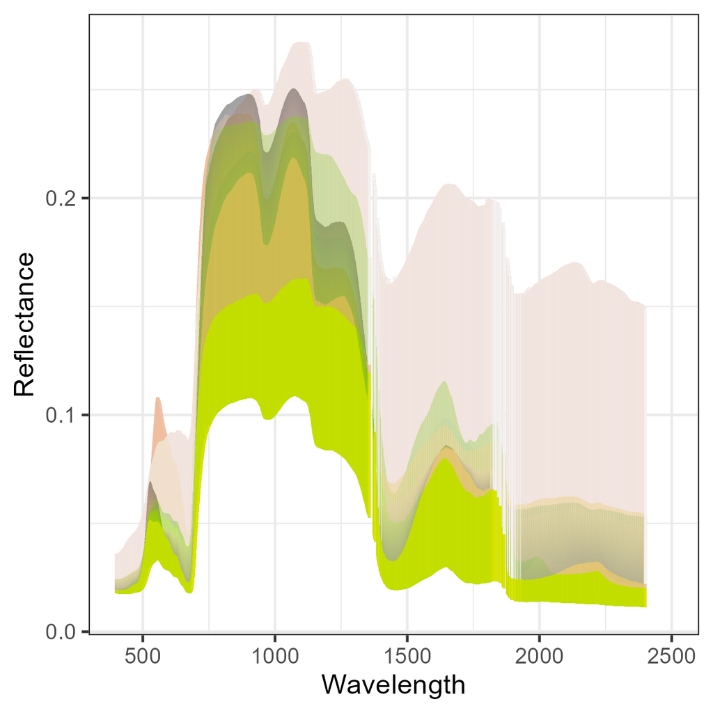

refl grouped by Vcmax25, produced by get.SCOPE.plots()

```r
refl_png <- png_files[grepl("^1-reflectance_refl_by_Vcmax25", basename(png_files))]
knitr::include_graphics(refl_png)
```

Reflectance averaged within each of the 8 `Vcmax25` bins – a quick way to see whether a trait leaves a visible signature on the spectrum before running a full inversion.

# Inverting traits from simulated reflectance

The apparent reflectance (`reflapp`) SCOPE produces is exactly the kind of “sensor-observed” spectrum inversion works from — same idea as the PROSAIL inversion in the ToolsRTM manual, just generated with a coupled energy-balance model instead of pure radiative transfer. This section runs the short version of that workflow; see `ToolsRTM_PROSAIL_tutorial.Rmd` for the full 12-algorithm reference and the deep-learning (CNN/Hidden-layers) path.

```r
inv_subdirs <- list.dirs(out_root, recursive = FALSE)
# A chunk can come back with no reflapp.csv if every simulation in it hit an
# unrecoverable error (e.g. a randomly-drawn LIDFa/LIDFb combination outside
# the physically valid range for fourSAIL) -- drop incomplete chunks rather
# than fail the whole comparison.
inv_subdirs <- inv_subdirs[file.exists(file.path(inv_subdirs, "reflapp.csv"))]
length(inv_subdirs)
```

```
## [1] 2
```

```r
lut_used <- do.call(rbind, lapply(inv_subdirs, function(d) {
  read.csv(file.path(d, "Parameters", "inputLUT.csv"))
}))
reflapp <- do.call(rbind, lapply(inv_subdirs, function(d) {
  read.csv(file.path(d, "reflapp.csv"))
}))

wlS <- SCOPEinR::define.bands()$wlS[1:2001]
colnames(reflapp) <- paste0("R.", wlS)

df.indices <- ToolsRTM::getIndices(reflapp, pattern.rfl = "R.", spectral.domain = "VNIR")
```

```
## [1] "Estimating indices using VNIR domain..."
##
```

```r
df.indices <- df.indices[, colSums(is.na(df.indices)) == 0]

target_wavelengths <- paste0("R.", seq(400, 800, by = 5))
dataset <- cbind(Cab = lut_used$Cab, reflapp[, target_wavelengths], df.indices)
dataset <- dataset[, !duplicated(names(dataset))]
dim(dataset)
```

```
## [1]   60 1968
```

Two `caret`-backed algorithms via `ToolsRTM::get.inversion()`, using the same interface the ToolsRTM manual documents in full for all 12 options:

```r
inputs_inv <- colnames(dataset)[-1]

inv_plsr <- get.inversion(data = dataset, depVar = "Cab", inputs = inputs_inv,
                           algorithm = "PLSR", n.samples = nrow(dataset), seed = 123)
```

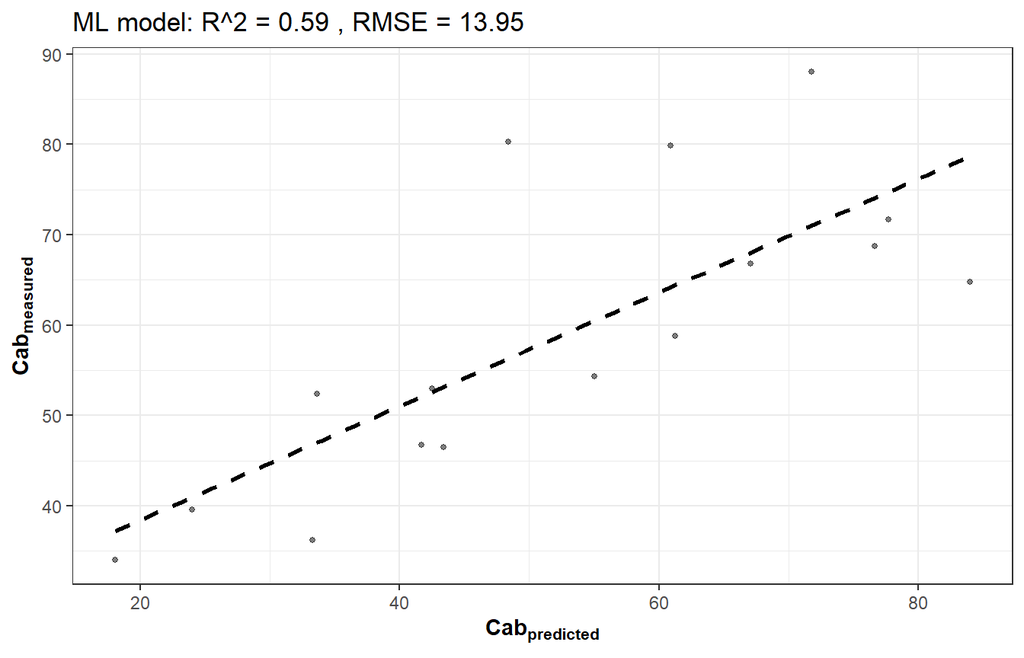

```r
inv_rf   <- get.inversion(data = dataset, depVar = "Cab", inputs = inputs_inv,
                           algorithm = "RF", n.samples = nrow(dataset), seed = 123)
```

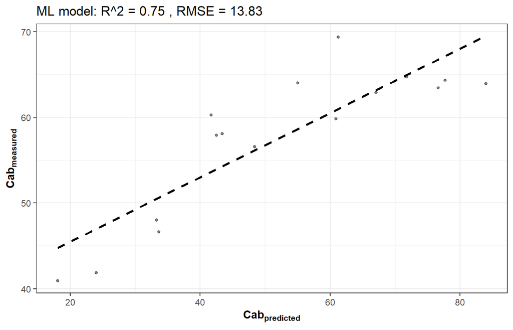

```r
cat("PLSR trained. Object class:", class(inv_plsr)[1], "\n")
```

```
## PLSR trained. Object class: list
```

```r
cat("RF trained. Object class:  ", class(inv_rf)[1], "\n")
```

```
## RF trained. Object class:   list
```

# Summary

| Want to… | Use |
| --- | --- |
| Run one simulation | `get.SCOPE(LUT[1, ], options.SCOPE, optipar, leaf.model, canopy.model, get.outputs, get.plots)` |
| Sample a random parameter set | `getLUT.SCOPE(inputLUT, nLUT, setseed)` |
| Correlate two traits (e.g. `LIDFa`/`LIDFb`) | `ToolsRTM::getCor(...)` |
| Run many simulations in parallel | `get.SCOPE.parallel(LUT, ..., parallel = TRUE, n.cores = , get.csv = TRUE, path.out = "somewhere/")` |
| Merge chunked CSV outputs | `read.csv()` + `rbind()` per chunk folder |
| Inspect reflectance/fluorescence/radiance by trait | `SCOPEinR:::get.SCOPE.plots(path.files, plant.trait, get.plots)` |
| Invert a trait from simulated `reflapp` | `ToolsRTM::getIndices()` + `ToolsRTM::get.inversion()` — full detail in `ToolsRTM_PROSAIL_tutorial.Rmd` |

Every code chunk above executed for real while writing this manual.